# Modellierung der Preis-Absatz Funktion

Karsten Lübke

17.04.2018

# 1. Forschungsfrage

Das Preismanagement ist eine zentrale Frage für Unternehmen, aber die Abschätzung der Zusammenhänge ist nicht einfach, siehe z. B. (Steiner and Weber 2010).

Es existieren verschiedene Modellierungsansätze für Preis-Absatz Funktionen. Hier ist der Preis $p$ die erklärende Variable, die Menge $q$ die erklärte Variable: $q=f(p)$, z. B.:

- Linear: $q=a-b\cdot p$. Vgl. $y=\beta_0 + \beta_1 \cdot x$.
- Multiplikativ: $q=a \cdot p^{-b}$. Vgl. $y=\beta_0 \cdot x^{\beta_1} \Leftrightarrow ln(y)=ln(\beta_0)+\beta_1 \cdot ln(x)$.

mit unbekannten Koeffizienten $a,b$ (bzw. $\beta_0, \beta_1$), die mit Hilfe von Daten geschätzt werden können.

Welche der Modellierungsansätze kann Preis-Absatz Funktionen besser beschreiben?

# 2. Studiendesign

Die Zahlungsbereitschaft wurde erhoben anhand der Frage: “Würden Sie das Produkt zum Preis $P$ kaufen?” vgl. z. B. (Adler 2003). Hier für eine fiktive organische Milch im Preisbereich $p=0.19, 0.29, 0.39, \ldots ,2.99$ (in Euro).

Die Teilnehmer*innen wurden anhand einer freiwilligen und anonymen Online Umfrage befragt.

# 3. Datenerhebung

Die Datenerhebung erfolgte über eine Verteilung des Umfragelinks im Freundes- und Bekanntenkreis. Die aufbereiteten Daten der Online Umfrage liegen als `csv` Datei vor. Es wurde je Preisstufe der Anteil der Personen ($n=104$) berechnet, die das Produkt zum angegebenen Preis kaufen würden.

```r
Milk <- read.csv2("http://www.statistix.org/Data/OrganicMilk.csv")
```

# 4. Datenanalyse

Datenbeschhreibung:

```r
# Ggfs. Paket mosaic installieren
# install.packages(mosaic)

# Paket laden
library("mosaic")

# Erste Datenübersicht
inspect(Milk)
```

```
##
## quantitative variables:
##       name   class  min   Q1 median    Q3    max     mean         sd  n
## 1    Price numeric 0.19 0.89   1.59  2.29   2.99  1.59000  0.8514693 29
## 2 Purchase integer 1.00 1.00  16.00 89.00 100.00 39.44828 40.9691401 29
##   missing
## 1       0
## 2       0
```

- `Price`: Preis der Milch.
- `Purchase`: Anteil der Personen, die die Milch zu dem Preis kaufen würden.

## Grafische Analyse

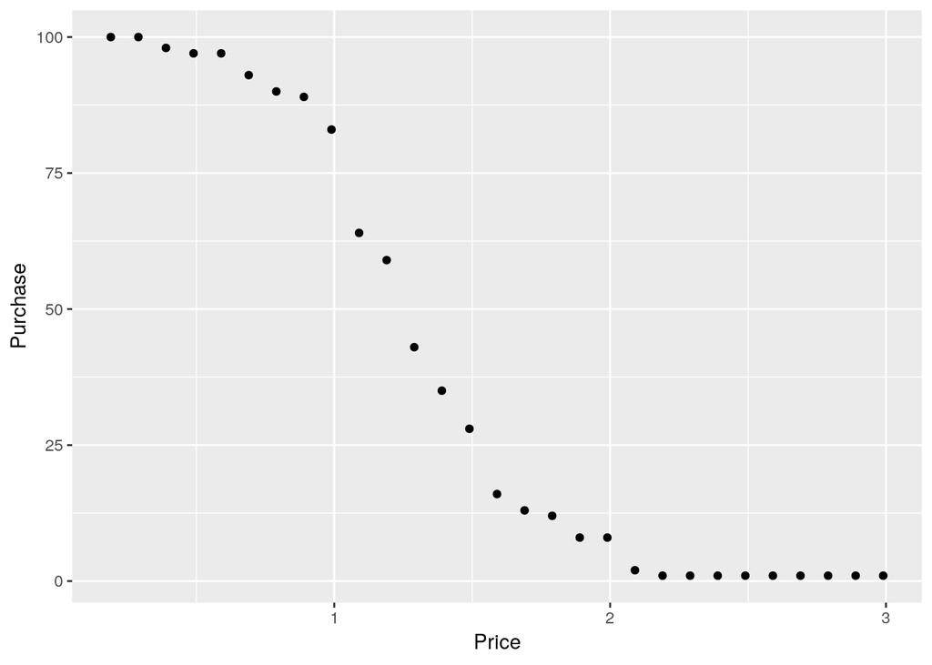

```r
gf_point(Purchase ~ Price, data = Milk)
```

Die grafische Analyse über das Streudiagramm zeigt einen fallenden Verlauf (je höher der Preis, desto geringer der Anteil der Leute, die das Produkt kaufen würden) als auch Sprungstellen.

## Kennzahlen

Die Korrelationskoeffizienten nach Pearson und auch Spearman bestätigen den optischen Eindruck, wobei die Rangkorrelation (Spearman) größer ist:

```r
cor(Purchase ~ Price, data = Milk, method ="pearson")
```

```
## [1] -0.9399529
```

```r
cor(Purchase ~ Price, data = Milk, method ="spearman")
```

```
## [1] -0.9847357
```

# 5. Modellierung

## Linear

Über den ganzen Wertebereich ist eine lineare Modellierung nicht sinnvoll:

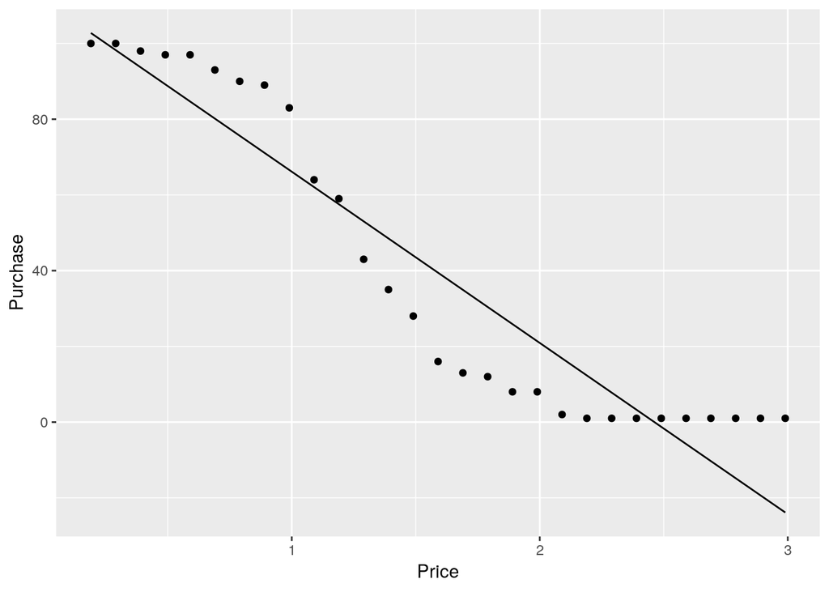

```r
linear1 <- lm(Purchase ~ Price, data = Milk)
gf_point(Purchase ~ Price, data = Milk) %>%
  gf_line(fitted(linear1) ~ Milk$Price)
```

*Hinweis*: Die über den gesamten Wertebereich von $x$ nicht angemessene lineare Modellierung erkennt man auch am Muster im Residualplot:

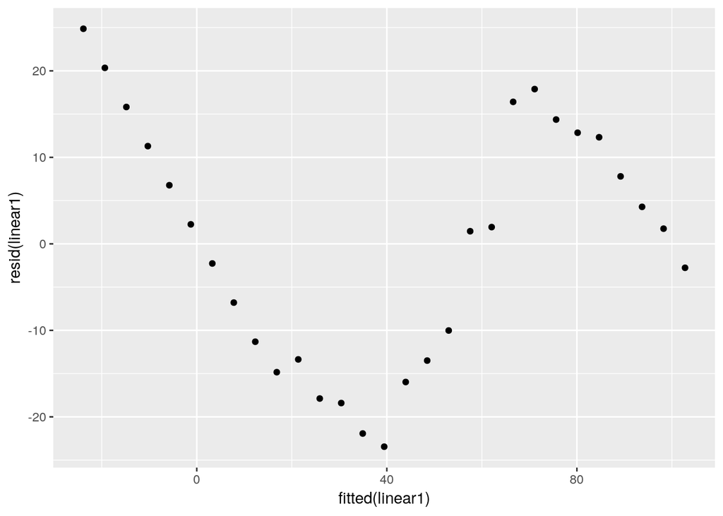

```r
gf_point(resid(linear1) ~ fitted(linear1))
```

Eine lokale Anpassung für den Bereich von $0.89$ bis $1.59$:

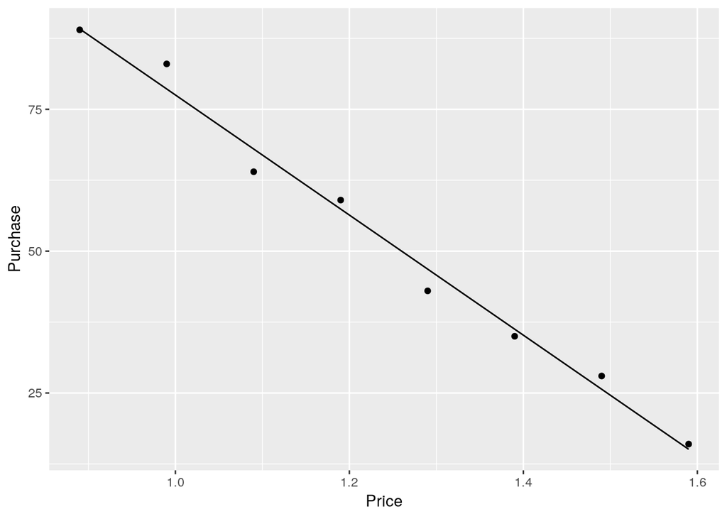

```r
Milk2 <- Milk %>%
  filter(0.89<=Price & Price<=1.59)

linear2 <- lm(Purchase ~ Price, data = Milk2)
gf_point(Purchase ~ Price, data = Milk2) %>%
  gf_line(fitted(linear2) ~ Milk2$Price)
```

```r
summary(linear2)
```

```
##
## Call:
## lm(formula = Purchase ~ Price, data = Milk2)
##
## Residuals:
##    Min     1Q Median     3Q    Max
## -4.000 -1.896  0.375  1.771  4.417
##
## Coefficients:
##             Estimate Std. Error t value Pr(>|t|)
## (Intercept)  183.358      6.183   29.66 9.75e-08 ***
## Price       -105.833      4.903  -21.59 6.45e-07 ***
## ---
## Signif. codes:  0 '***' 0.001 '**' 0.01 '*' 0.05 '.' 0.1 ' ' 1
##
## Residual standard error: 3.178 on 6 degrees of freedom
## Multiple R-squared:  0.9873, Adjusted R-squared:  0.9852
## F-statistic: 465.9 on 1 and 6 DF,  p-value: 6.454e-07
```

Innerhalb des Wertebereiches zwischen $0.89$€ und $1.59$€ gilt als Schätzgleichung:

$$\hat{y}=183.36 - 105.83\cdot x$$

D. h., pro $0.10$€ wird in diesem Wertebereich ein Rückgang des Mittelwertes der Zahlungsbereitschaft um 10.58$\%$ beobachtet. Eine Extrapolation sollte nicht erfolgen. Allerdings ist in diesem Bereich die Anpassung sehr gut: $R^2=0.987$.

Die Nullhypothese “Es gibt keinen linearen Zusammenhang zwischen Preis und Absatz”, d. h. $H_0: \beta_P=0$ wird mit einem P-Wert von $6.4541138\times 10^{-7}$ verworfen ($\alpha=0.001$).

## Multiplikativ

Über den ganzen Wertebereich ist auch eine multiplikative Modellierung nicht sinnvoll:

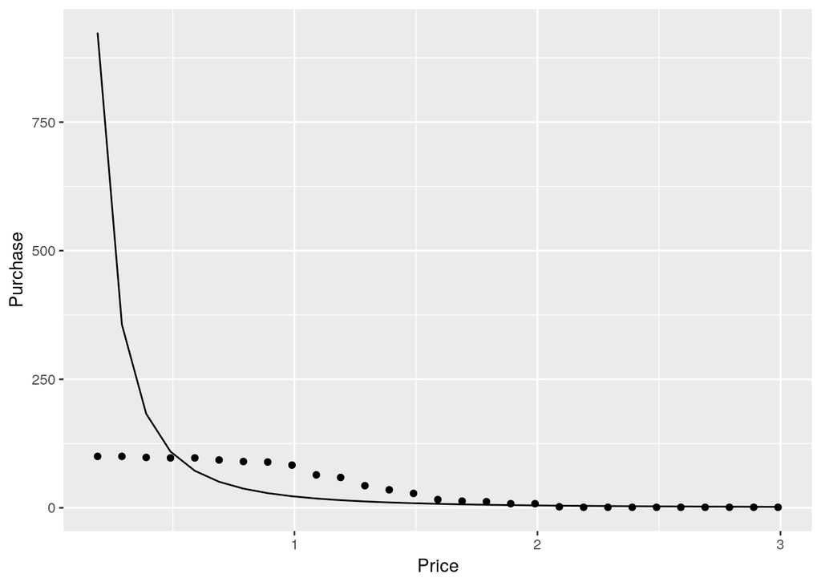

```r
multi1 <- lm(log(Purchase) ~ log(Price), data = Milk)
gf_point(Purchase ~ Price, data = Milk) %>%
  gf_line(exp(fitted(multi1)) ~ Milk$Price)
```

Eine Anpassung im Wertebereich $1.09$ bis $2.99$ sieht wie folgt aus:

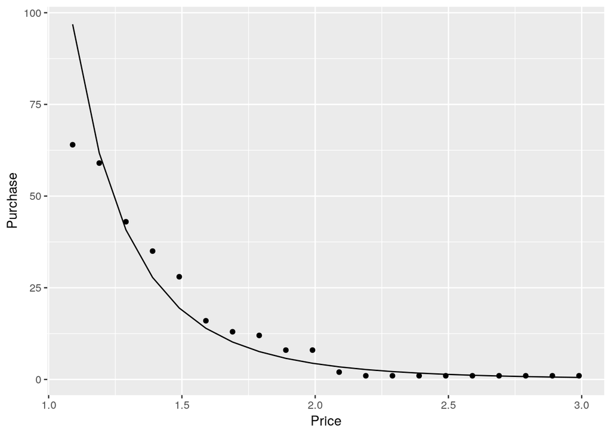

```r
Milk2 <- Milk %>%
  filter(1.09<=Price & Price<=2.99)

multi2 <- lm(log(Purchase) ~ log(Price), data = Milk2)
gf_point(Purchase ~ Price, data = Milk2) %>%
  gf_line(exp(fitted(multi2)) ~ Milk2$Price)
```

```r
summary(multi2)
```

```
##
## Call:
## lm(formula = log(Purchase) ~ log(Price), data = Milk2)
##
## Residuals:
##     Min      1Q  Median      3Q     Max
## -0.9922 -0.3535  0.1002  0.3392  0.6059
##
## Coefficients:
##             Estimate Std. Error t value Pr(>|t|)
## (Intercept)   5.0154     0.2580   19.44 1.57e-13 ***
## log(Price)   -5.1324     0.3514  -14.61 2.01e-11 ***
## ---
## Signif. codes:  0 '***' 0.001 '**' 0.01 '*' 0.05 '.' 0.1 ' ' 1
##
## Residual standard error: 0.4722 on 18 degrees of freedom
## Multiple R-squared:  0.9222, Adjusted R-squared:  0.9179
## F-statistic: 213.3 on 1 and 18 DF,  p-value: 2.012e-11
```

In diesem Bereich gilt in diesem Modell:

$$\hat{y}=e^{5.02}\cdot x^{-5.13}$$
D. h., die geschätzte Preiselastizität der Nachfrage liegt hier bei $-5.13$. Auch hier ist die Anpassung gut: in diesem Bereich werden auf logarithmischer Skala $R^2=0.922$ der Variation der Nachfrage modelliert[^1] und $H_0: \beta_P=0$ wird verworfen ($\alpha=0.001$).

# 6. Schlussfolgerungen

In den vorliegenden Daten können weder das lineare noch das multiplikative Modell die Preis-Absatz Funktion über den ganzen Wertebereich modellieren - es sind nur lokale Anpassungen sinnvoll.

Außerdem wurde nur die fiktive Kaufabsicht einer Gelegenheitsstichprobe erhoben, es wurden keine realen Kaufdaten verwendet.

## Ausblick

Eine flexible Alternative ist die Spline Regression. Hier wird der Wertebereich von $x$ in Intervalle aufgeteilt und innerhalb dieser Intervalle werden Polynome angepasst, wobei die Übergänge geglättet werden, siehe z. B. (James et al. 2013).

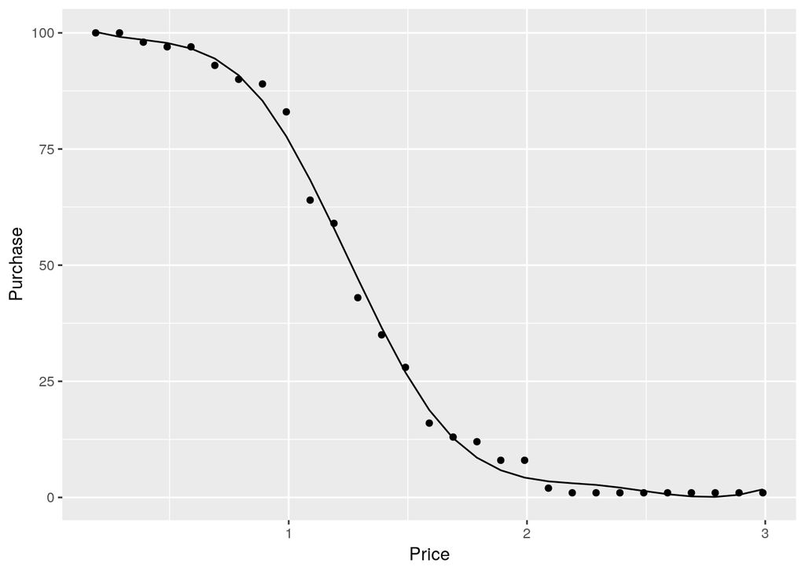

```r
# Paket laden
library(splines)

splines <- lm(Purchase ~ bs(Price,
                            knots=quantile(Price, probs=c(0.25, 0.50, 0.75)),
                            degree=3),
              data=Milk)

gf_point(Purchase ~ Price, data = Milk) %>%
  gf_line(fitted(splines) ~ Milk$Price)
```

Die Interpretation der Koeffizienten (vgl. `summary(splines)`) ist schwierig. Aber man kann erkennen, dass die Anpassung über den ganzen Wertebereich gut ist: $R^2=0.997$.

# Danksagung

Die Daten wurden innerhalb der Bachelor Thesis zum Thema “Spline Regression as a Method to Estimate Price Response Functions” erhoben.

# Anhang: Versionshinweise

- Datum erstellt: 2019-06-14
- R Version: 3.6.0

Verwendete Pakte:

- `mosaic` Version: 1.5.0
- `ggformula` Version: 0.9.1
- `splines` Version: 3.6.0

# Literatur

Adler, Jost. 2003. “Möglichkeiten Der Messung von Zahlungsbereitschaften Der Nachfrager.” *Duisburger Arbeitspapiere Zum Marketing* 7.

James, Gareth, Daniela Witten, Trevor Hastie, and Robert Tibshirani. 2013. *An Introduction to Statistical Learning*. Springer.

Steiner, Winfried J, and Anett Weber. 2010. “Methoden Zur Schätzung von Preis-Absatz-Funktionen.” *Wirtschaftsstudium-WISU* 39 (1): 121–28.

[^1]: $R^2$ von transformierten und untransformierten Variablen $y$ können nicht direkt verglichen werden.